# Team project: Checkpoint

R for Data Science @ Hult University

Team 3 - Victoria Padua, Wai Hoi Li

# Set-up

```r
# Load package
library(tidyverse)
```

# Abstract

## Topic

Logistics & transportation industry, more specifically shipping price, is highly dependent on oil price variation, provoking a direct effect on the company profit.

## Motivation and background

The relationship between oil price and shipping price has two-sides effect. On one hand, lower oil prices benefit carriers, allowing faster shipments and fomenting just-in-time delivery. Conversely, higher oil prices drive delivery services companies to increase shipping costs or assume losses (American Express, n.f.). In addition, oil substitutes, such as CNG biofuels and electricity are scarcely used in the industry and is expected to be an ideal alternative that can reduce uncertainty while increasing profit.

## Objectives

The objective is to demonstrate the benefits in profit as a result of the implementation of renewable energies on the logistics and transportation industry in the United States, considering only the land transportation as a pilot project given that it is the most common transportation mode in the industry.

## Plan

The plan to demonstrate how it is more profitable for logistics and transportation companies to implement more environment friendly solutions such as electric trucks, is:

Step 1.To analyze how fluctuatingis the oil variation across the last ten years, through a time series, to have an understanding of the variation of shipment prices overtime.

Step 2. To demonstrate the most common fuel type in the US in the last year (2019). Using a bar chart per fuel type, we could do a general exploration of the use of the different fuel types, and evaluate the alternatives of the use of petroleum-based energy sources

Step 3. Finally Compare and contraste the cost of the different types of energy analyzed in the following study (diesel or electric) displaying a stacked bar chart by the list of types of trucks that are part of the delivery service companies’ fleet.

Step 4. To compare the cost of increasing the fleet on both, electric and diesel, by type of truck with a stacked bar chart.

# Data

## Background

[Freight transport](https://data.oecd.org/transport/freight-transport.htm) Freight transport is a data for recording the total movement of good using inland transportation. We collected this data because we could like to understand the differences on in-land freight transport comparing the US and some of the chosen countries.

[NASDAQ:CL:NMX Historical Data](https://www.nasdaq.com/market-activity/commodities/cl%3Anmx/historical) This is the historical trading price for the crude oil. The unit of the price is USD/bbl, and bbl is the abbreviation for barrel for oil. We have chosen this data because we could like to investigate the change of oil price across the years.

[Energy use for transportation](https://www.eia.gov/energyexplained/use-of-energy/transportation.php) This data is collected from the U.S. Energy Information Administration. We have chosen this data because we could like to have a grasp understanding on what is the type of energy usage based on transportation.

[Electrifying Trucks: From Delivery Vans to Buses to 18-Wheelers](https://www.aceee.org/sites/default/files/pdfs/electric_trucks_1.pdf) This data is collected from the American Council for an Energy-Efficient Economy. The reason of choosing this dataset is because we could like to explore the cost of energy and truck based on truck type and fuel type.

## Key variables

```r
# Import all csv
tsi = read_csv("TransportationServicesIndex.csv")
transport_countries = read_csv("oecd_freight_transport.csv")
fuel_consumption = read_csv("fuel_consumption_transportation18_trillion_btu.csv")
crude_oil_price_yearly = read_csv("HistoricalQuotes.csv")
transportation_energy_source = read_csv("transportation-energy-source-fuels2019.csv")
energy_cost_comparison_2018 = read_csv("comparison_annula_energy_cost_diesel_vs_electric_trucks.csv")
```

```r
# Display the first 5 rows to confirm import successful
tsi %>% slice_head(n=5)
```

| date | day | month | year | freight | passengers | total |
| --- | --- | --- | --- | --- | --- | --- |
| Jan-00 | 1 | 1 | 2000 | 105.3 | 94.8 | 101.8 |
| Feb-00 | 1 | 2 | 2000 | 104.4 | 98.1 | 102.3 |
| Mar-00 | 1 | 3 | 2000 | 99.1 | 99.0 | 99.1 |
| Apr-00 | 1 | 4 | 2000 | 98.1 | 99.4 | 98.5 |
| May-00 | 1 | 5 | 2000 | 98.6 | 101.2 | 99.4 |

```r
transport_countries %>% slice_head(n=5)
```

| location | indiccator | subject | measure | frequency | year | value | flag_codes |
| --- | --- | --- | --- | --- | --- | --- | --- |
| AUS | FREIGHTTRANSP | ROAD | MLN_TONNEKM | A | 1996 | 107403.2 | NA |
| AUS | FREIGHTTRANSP | ROAD | MLN_TONNEKM | A | 1997 | 113423.8 | NA |
| AUS | FREIGHTTRANSP | ROAD | MLN_TONNEKM | A | 1998 | 119344.6 | NA |
| AUS | FREIGHTTRANSP | ROAD | MLN_TONNEKM | A | 1999 | 125015.8 | NA |
| AUS | FREIGHTTRANSP | ROAD | MLN_TONNEKM | A | 2000 | 132618.0 | NA |

```r
fuel_consumption %>% slice_head(n=5)
```

| year | Air | Certificated Carriers | air_certificated_carriersjet_fuel | General Aviation | air_general_aviation_gasoline | air_jet_fuel | Highway | Gasoline, diesel and other fuels | highway_light_duty_vehicle_short_wheel_base_and_motorcycle | highway_light_duty_vehicle_long_wheel_base | highway_single_unit_2_axle_6_tire_or_more_truck | highway_combination_truck | highway_bus | Transit | transit_electricity | Motor fuel | transit_motor_fuel_dieself | transit_motor_fuel_gasoline_and_other_nondiesel_fuels | transit_motor_fuel_compressed_natural_gas | Rail, Class I (in freight service) | class_1rail_distillate_diesel fuel | Amtrak | amtrak_electricity | amtrak_distillate_diesel fuel | Water | water_residual_fuel_oil | water_distillate_diesel fuel oil | water_gasoline | Pipeline | … |
| --- | --- | --- | --- | --- | --- | --- | --- | --- | --- | --- | --- | --- | --- | --- | --- | --- | --- | --- | --- | --- | --- | --- | --- | --- | --- | --- | --- | --- | --- | --- |
| 1960 | NA | NA | 264 | NA | 29 | N | NA | NA | 5146 | NA | NA | NA | 103 | NA | 10 | NA | 29 | 24 | NA | NA | 480 | NA | NA | NA | NA | 592 | 109 | NA | NA | … |
| 1965 | NA | NA | 525 | NA | 35 | 8 | NA | NA | 6215 | NA | 1731 | 832 | 109 | NA | 9 | NA | 34 | 16 | NA | NA | 498 | NA | NA | NA | NA | 463 | 90 | NA | NA | … |
| 1970 | NA | NA | 1061 | NA | 66 | 28 | NA | NA | 8485 | 1539 | 496 | 918 | 103 | NA | 9 | NA | 38 | 9 | NA | NA | 492 | NA | NA | NA | NA | 565 | 114 | 75 | NA | … |
| 1975 | NA | NA | 1020 | NA | 50 | 61 | NA | NA | 9282 | 2385 | 678 | 1147 | 132 | NA | 9 | NA | 51 | 1 | NA | NA | 507 | NA | 1 | 9 | NA | 608 | 152 | 91 | NA | … |
| 1980 | NA | NA | 1150 | NA | 63 | 103 | NA | NA | 8773 | 2975 | 865 | 1630 | 127 | NA | 8 | NA | 60 | 1 | NA | NA | 541 | NA | 1 | 9 | NA | 1340 | 205 | 132 | NA | … |

```r
crude_oil_price_yearly %>% slice_head(n=5)
```

| Date | Close_Last | Volume | Open | High | Low |
| --- | --- | --- | --- | --- | --- |
| 2020-12-08 | 45.60 | 306224 | 45.66 | 45.93 | 45.14 |
| 2020-12-07 | 45.76 | 324354 | 46.15 | 46.54 | 45.58 |
| 2020-12-04 | 46.26 | 317929 | 45.64 | 46.68 | 45.61 |
| 2020-12-03 | 45.64 | 333384 | 44.99 | 45.84 | 44.66 |
| 2020-12-02 | 45.28 | 347720 | 44.38 | 45.61 | 44.80 |

```r
transportation_energy_source %>% slice_head(n=5)
```

| fuel_type | percentage_2019 |
| --- | --- |
| gasoline (petroleum) | 53 |
| distillates (petroleum) | 22 |
| jet fuel (petroleum) | 13 |
| other | 3 |
| biofuels | 5 |

# Exploratory data analysis

### Graph1

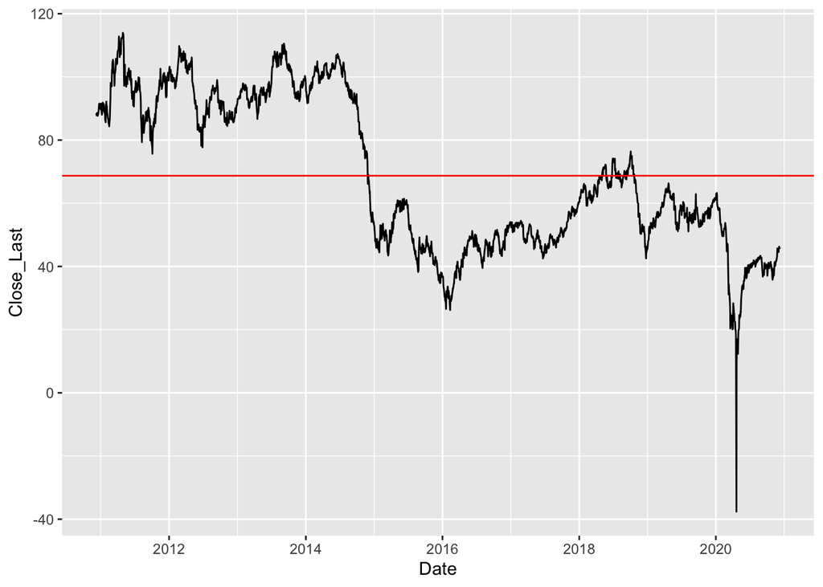

```r
crude_oil_price_yearly %>%
    group_by(Date) %>%
    ggplot(data = ., aes(x= Date, y=  Close_Last))+
    geom_line()+
    geom_hline(yintercept = mean(crude_oil_price_yearly$Close_Last), colour = "red")
```

Translating this fact to the logistics and transportation industry, it means that carriers have to constantly adjust their prices and operations dynamic to be able to maintain and/or increase profit.

Why is oil price so significant for the industry? This question is answered in the following chart:

### Graph2

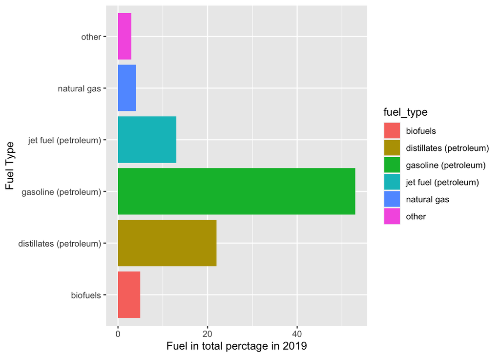

```r
transportation_energy_source %>%
    ggplot(data = ., aes(x = percentage_2019, y = fuel_type,fill = fuel_type))+
    geom_bar(stat='identity')+
    labs(y="Fuel Type", x="Fuel in total perctage in 2019")
```

With that in mind, the evaluation of alternatives are necessary to reduce uncertainty. Reason why we compare the cost of electric trucks against diesel:

### Graph3

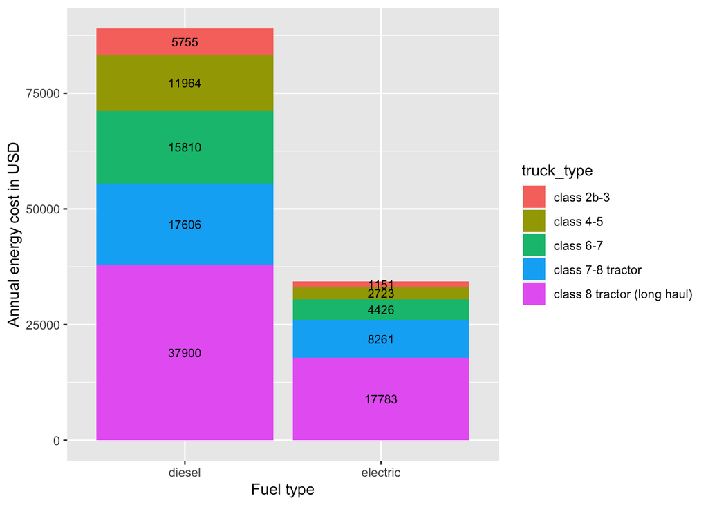

```r
energy_cost_comparison_2018 %>%
    ggplot(data = ., aes(x = energy_type, y = annual_energy_costs_US, fill = truck_type))+
    geom_bar(stat='identity')+
    geom_text(aes(label=annual_energy_costs_US), colour = "black", size=3, position = position_stack(vjust = 0.5))+
    labs(x="Fuel type", y="Annual energy cost in USD")
```

The difference in cost would greatly benefit Logistic companies reason why we decided to move forward and evaluate what would cost the fleet increase?

### Graph4

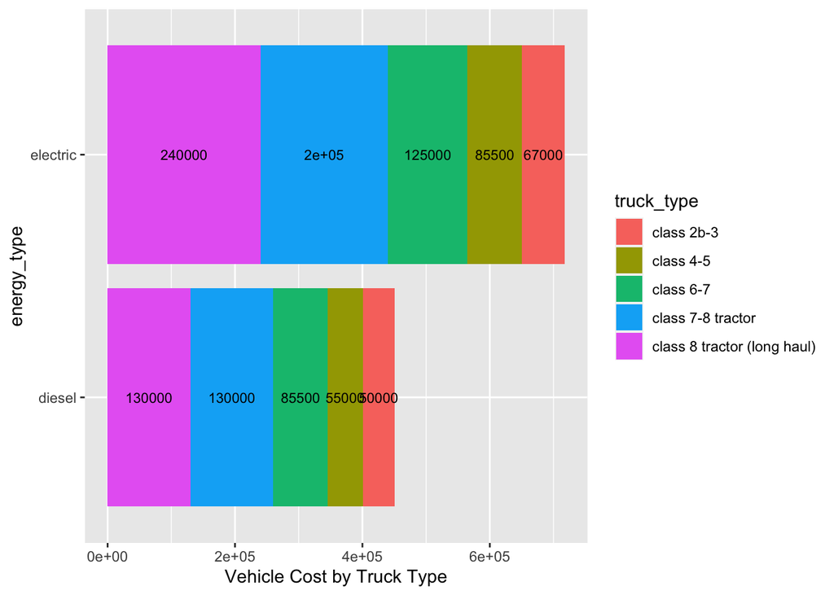

```r
energy_cost_comparison_2018 %>%
    ggplot(data = ., aes(x = energy_type, y = approx_upfront_cost_USD, fill = truck_type))+
    geom_bar(stat='identity')+
    geom_text(aes(label=approx_upfront_cost_USD), colour = "black", size=3, position = position_stack(vjust = 0.5))+coord_flip()+
    labs(x="energy_type", y="Vehicle Cost by Truck Type")
```

As a result, it is very costly to implement electric trucks in the industry and the decision entails very high risks that need further exploration

# Analysis plan

We will first start by finding out the crude oil usage of truck in the freight industry. Then, we will need to find out the percentage of fuel expenses in the industry. This will be calculated by randomly choosing 5 listed logistic companies in the top 50 in terms of company size in the Sates. We will then record down the fuel expensive proportion based on their income statement. Afterwards, we will generate a regression model to test if the shipping cost is related to the oil price. If we confirmed there is a relationship between oil price and shipping cost, then we will move on to generate the cost variances between oil and electric.

# Issues

Data gathering issues: Our data doesn’t fully cover the analysis topic because finding data specifically targeting the electric car, such as the charging price in gas station for electric car in the past 10 years, is difficult.